# Dataset: ‘dataset_1’ LASSO summary

# Dataset: ‘dataset_6’ LASSO summary

## Full model prediction accuracy

| drug | 1 | 0 | 1/1 | 1/0 | 0/1 | 0/0 | precission | recall | f1 | accuracy |
| --- | --- | --- | --- | --- | --- | --- | --- | --- | --- | --- |
| AMIK | 59 | 63 | 0.4672 | 0.0164 | 0.0164 | 0.5000 | 0.9661 | 0.9661 | 0.9661 | 0.9672 |
| CAPR | 66 | 51 | 0.5641 | 0.0000 | 0.0000 | 0.4359 | 1.0000 | 1.0000 | 1.0000 | 1.0000 |

## Reduced model prediction accuracy

| drug | 1 | 0 | 1/1 | 1/0 | 0/1 | 0/0 | precission | recall | f1 | accuracy |
| --- | --- | --- | --- | --- | --- | --- | --- | --- | --- | --- |
| AMIK | 59 | 63 | 0.4836 | 0 | 0.0082 | 0.5082 | 0.9833 | 1 | 0.9916 | 0.9918 |
| CAPR | 66 | 51 | 0.5641 | 0 | 0.0000 | 0.4359 | 1.0000 | 1 | 1.0000 | 1.0000 |

## ‘AMIK’ Details

### Elastic Net for Best Lambda

Lambda that minimizes CV error

```
## [1] 0.04
```

Corresponding CV error

```
## [1] 0.8952
```

Number of nonzero coefficients (all non-zero)

```
## s48
##  53
```

Nonzero coefficients*:

| position | bp | coeficient |
| --- | --- | --- |
| 11 | 7572 | -0.6961 |
| 12 | 7581 | -1.9764 |
| 13 | 7582 | -0.3561 |
| 32 | 37031 | 0.1393 |
| 48 | 75937 | -0.3891 |
| 55 | 96675 | -0.2254 |
| 66 | 104912 | 0.7137 |
| 87 | 209944 | 1.7678 |
| 91 | 295644 | 0.6281 |
| 92 | 295731 | 0.0650 |
| 93 | 301489 | -0.8712 |
| 94 | 302537 | 1.5213 |
| 98 | 333624 | -0.1283 |
| 99 | 333628 | -0.5029 |
| 101 | 333637 | -0.2773 |
| 166 | 487328 | 1.8548 |
| 167 | 528976 | 0.0713 |
| 177 | 761158 | 0.3520 |
| 181 | 781825 | -1.1935 |
| 190 | 854607 | -0.5232 |
| 193 | 889037 | -0.0636 |
| 208 | 973064 | 0.2851 |
| 209 | 1001128 | -0.8565 |
| 226 | 1096571 | 0.2875 |
| 253 | 1276437 | 0.2116 |
| 260 | 1276887 | 0.6011 |
| 270 | 1342069 | 0.0290 |
| 277 | 1409480 | -0.2228 |
| 290 | 1519836 | 1.3220 |
| 310 | 1624797 | 0.3500 |
| 313 | 1633645 | 0.0797 |
| 316 | 1634598 | 0.6867 |
| 326 | 1636952 | 0.1334 |
| 374 | 1996121 | -0.9394 |
| 395 | 2155175 | 0.3155 |
| 427 | 2264790 | -0.0268 |
| 460 | 2536839 | 1.3125 |
| 465 | 2626610 | 0.0294 |
| 477 | 2829271 | 0.0260 |
| 497 | 2973473 | 0.0117 |
| 550 | 3730787 | 0.4820 |
| 551 | 3730813 | 0.1497 |
| 556 | 3732541 | 0.7264 |
| 557 | 3732795 | 0.6335 |
| 566 | 3736102 | 0.2377 |
| 617 | 3895282 | 0.2118 |
| 622 | 3927717 | -0.1644 |
| 632 | 3934118 | -0.3211 |
| 636 | 3936269 | 0.1046 |
| 649 | 3942660 | 0.4151 |
| 660 | 3946974 | 0.7391 |
| 673 | 4053229 | -0.0040 |
| 678 | 4121290 | 0.8505 |

### Charts

Nonzero coefficients (LASSO):

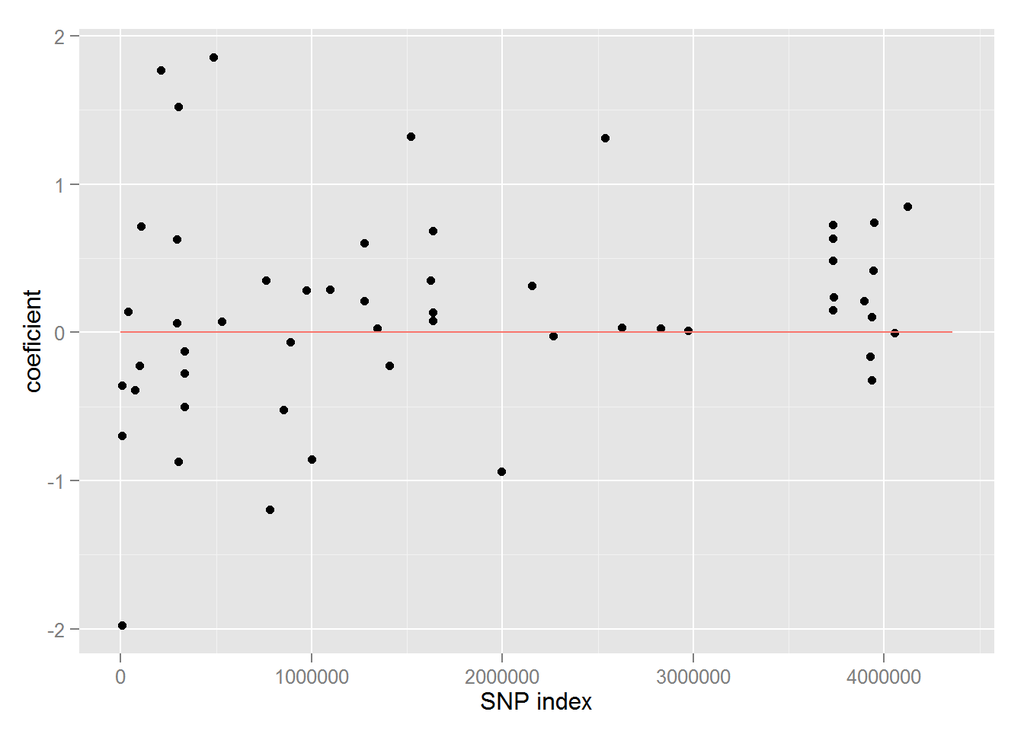

ROC curve for full model

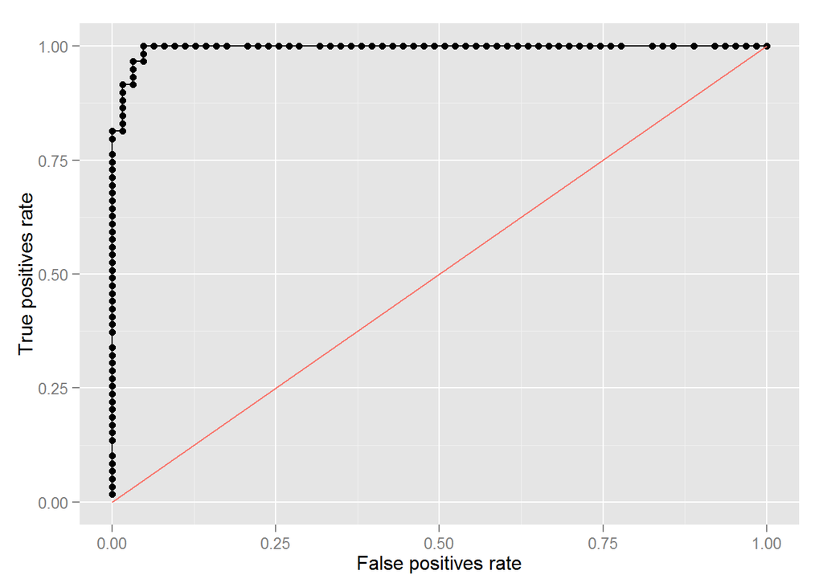

ROC curve for reduced model

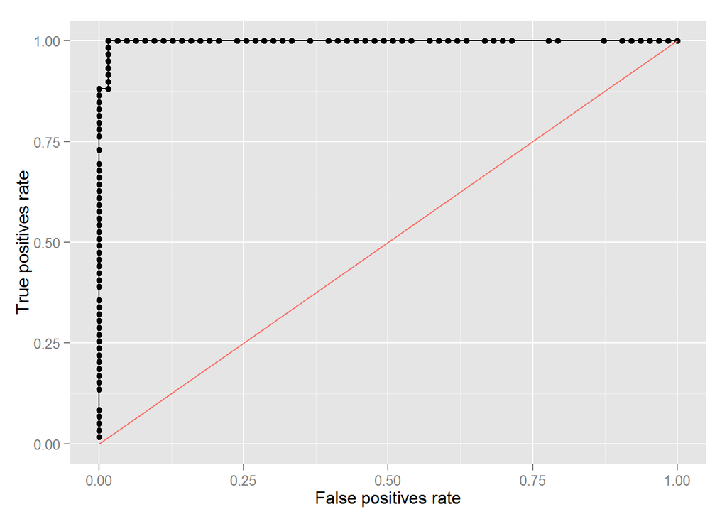

## ‘CAPR’ Details

### Elastic Net for Best Lambda

Lambda that minimizes CV error

```
## [1] 0.02
```

Corresponding CV error

```
## [1] 0.7291
```

Number of nonzero coefficients (all non-zero)

```
## s49
##  65
```

Nonzero coefficients*:

| position | bp | coeficient |
| --- | --- | --- |
| 9 | 6620 | -0.0462 |
| 10 | 7570 | -0.2495 |
| 11 | 7572 | -0.3395 |
| 12 | 7581 | -1.0407 |
| 13 | 7582 | -0.7949 |
| 17 | 11370 | -0.1012 |
| 40 | 60224 | 0.5383 |
| 48 | 75937 | -0.5345 |
| 53 | 87375 | -0.0349 |
| 66 | 104912 | 2.8407 |
| 82 | 154189 | 0.3671 |
| 84 | 173931 | 0.0538 |
| 86 | 202369 | -2.3920 |
| 87 | 209944 | 2.7742 |
| 90 | 285751 | 0.3001 |
| 92 | 295731 | 0.5738 |
| 94 | 302537 | 2.4540 |
| 98 | 333624 | -0.1682 |
| 99 | 333628 | -0.5151 |
| 104 | 335845 | 0.2962 |
| 130 | 338768 | 0.4377 |
| 166 | 487328 | 4.4323 |
| 177 | 761158 | 0.1274 |
| 179 | 770090 | 0.3083 |
| 181 | 781825 | -0.7050 |
| 187 | 837914 | 0.5286 |
| 190 | 854607 | -0.2361 |
| 208 | 973064 | 1.0093 |
| 209 | 1001128 | -0.8048 |
| 219 | 1096006 | -0.2355 |
| 226 | 1096571 | 0.4642 |
| 229 | 1164575 | 0.1944 |
| 237 | 1191468 | 0.3264 |
| 239 | 1191746 | 0.2749 |
| 260 | 1276887 | 0.3215 |
| 290 | 1519836 | 2.7677 |
| 310 | 1624797 | 0.3467 |
| 313 | 1633645 | 1.4448 |
| 314 | 1634424 | 0.2479 |
| 316 | 1634598 | 2.1097 |
| 326 | 1636952 | 0.0064 |
| 327 | 1636986 | -0.0684 |
| 331 | 1637203 | 0.1096 |
| 395 | 2155175 | 0.7652 |
| 412 | 2169072 | -1.0664 |
| 413 | 2196722 | 0.0028 |
| 427 | 2264790 | -0.2513 |
| 460 | 2536839 | 2.4700 |
| 465 | 2626610 | 1.0118 |
| 541 | 3710566 | 0.5442 |
| 550 | 3730787 | 0.4845 |
| 557 | 3732795 | 0.4668 |
| 616 | 3895261 | -0.4995 |
| 618 | 3895290 | -0.0643 |
| 622 | 3927717 | -0.2066 |
| 636 | 3936269 | 2.6797 |
| 640 | 3936487 | 0.4708 |
| 647 | 3936517 | -0.2200 |
| 649 | 3942660 | 1.5106 |
| 652 | 3943318 | -0.2874 |
| 660 | 3946974 | 2.4288 |
| 672 | 4016598 | 0.3881 |
| 673 | 4053229 | -0.4475 |
| 678 | 4121290 | 1.2302 |
| 683 | 4210452 | -0.1102 |

### Charts

Nonzero coefficients (LASSO):

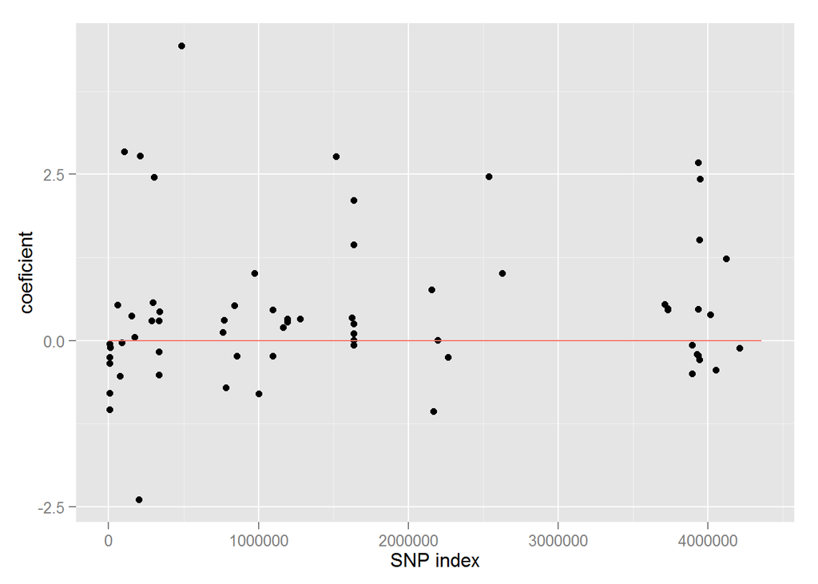

ROC curve for full model

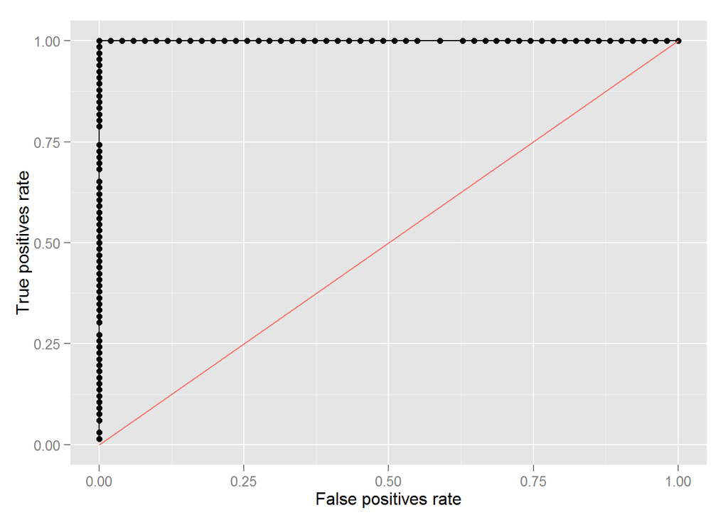

ROC curve for reduced model

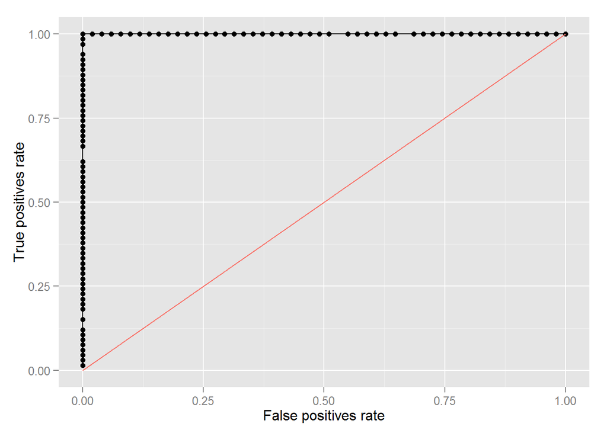

# Dataset: ‘dataset_7’ LASSO summary

## Full model prediction accuracy

| drug | 1 | 0 | 1/1 | 1/0 | 0/1 | 0/0 | precission | recall | f1 | accuracy |
| --- | --- | --- | --- | --- | --- | --- | --- | --- | --- | --- |
| AMIK | 8 | 21 | 0.2414 | 0.0345 | 0 | 0.7241 | 1 | 0.875 | 0.9333 | 0.9655 |
| CAPR | 10 | 18 | 0.3571 | 0.0000 | 0 | 0.6429 | 1 | 1.000 | 1.0000 | 1.0000 |

## Reduced model prediction accuracy

| drug | 1 | 0 | 1/1 | 1/0 | 0/1 | 0/0 | precission | recall | f1 | accuracy |
| --- | --- | --- | --- | --- | --- | --- | --- | --- | --- | --- |
| AMIK | 8 | 21 | 0.2759 | 0 | 0 | 0.7241 | 1 | 1 | 1 | 1 |
| CAPR | 10 | 18 | 0.3571 | 0 | 0 | 0.6429 | 1 | 1 | 1 | 1 |

## ‘AMIK’ Details

### Elastic Net for Best Lambda

Lambda that minimizes CV error

```
## [1] 0.14
```

Corresponding CV error

```
## [1] 0.88
```

Number of nonzero coefficients (all non-zero)

```
## s43
##   7
```

Nonzero coefficients*:

| position | bp | coeficient |
| --- | --- | --- |
| 5 | 6579 | -1.8229 |
| 37 | 333624 | -0.5937 |
| 81 | 1001128 | -0.1984 |
| 141 | 2196889 | -0.4958 |
| 142 | 2220520 | -0.2111 |
| 169 | 3382124 | -1.1112 |
| 186 | 3927774 | -0.8215 |

### Charts

Nonzero coefficients (LASSO):

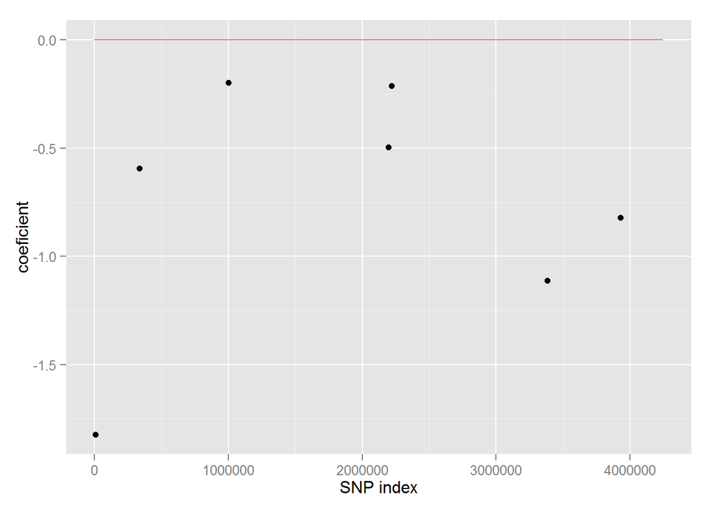

ROC curve for full model

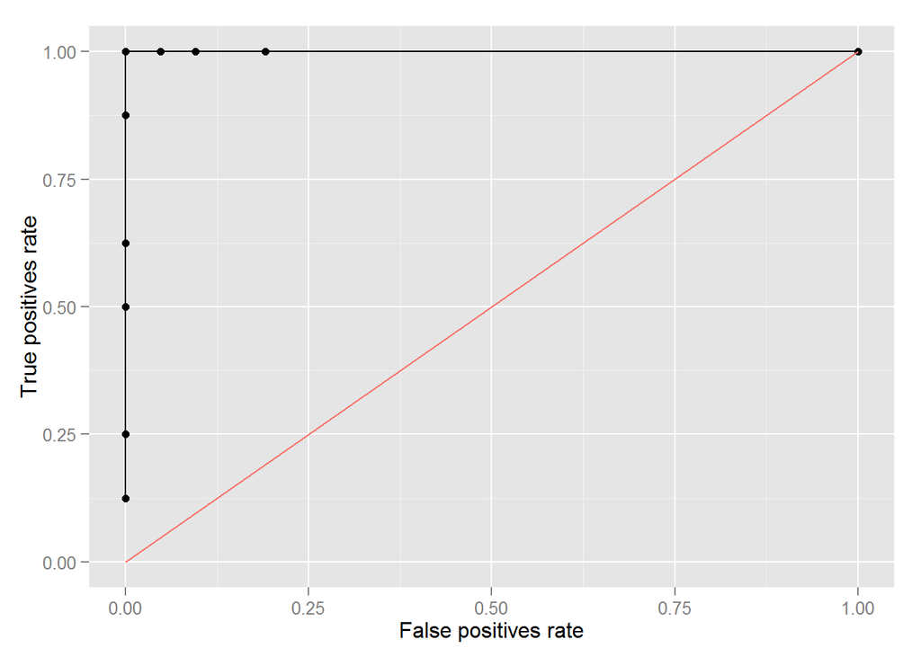

ROC curve for reduced model

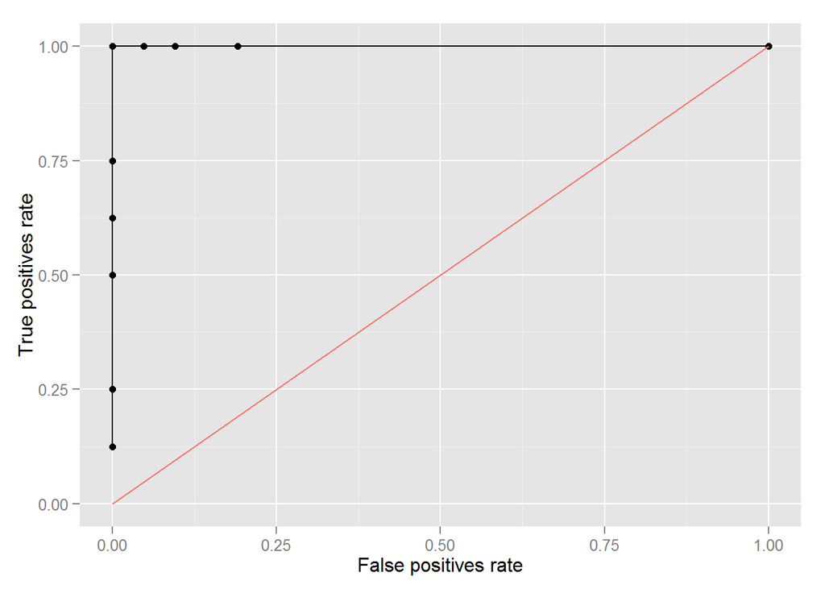

## ‘CAPR’ Details

### Elastic Net for Best Lambda

Lambda that minimizes CV error

```
## [1] 0.1
```

Corresponding CV error

```
## [1] 1.328
```

Number of nonzero coefficients (all non-zero)

```
## s45
##  16
```

Nonzero coefficients*:

| position | bp | coeficient |
| --- | --- | --- |
| 5 | 6579 | -2.0772 |
| 28 | 104938 | -0.2151 |
| 32 | 202369 | -1.9995 |
| 37 | 333624 | -0.3533 |
| 41 | 335971 | 0.2277 |
| 50 | 338618 | 0.3896 |
| 81 | 1001128 | -0.1930 |
| 87 | 1104278 | -0.0098 |
| 92 | 1191746 | -0.1427 |
| 118 | 1637210 | -0.0553 |
| 141 | 2196889 | -0.4408 |
| 142 | 2220520 | -0.2908 |
| 151 | 2536609 | 0.2255 |
| 169 | 3382124 | -0.9527 |
| 186 | 3927774 | -1.2165 |
| 196 | 3943314 | -0.1843 |

### Charts

Nonzero coefficients (LASSO):

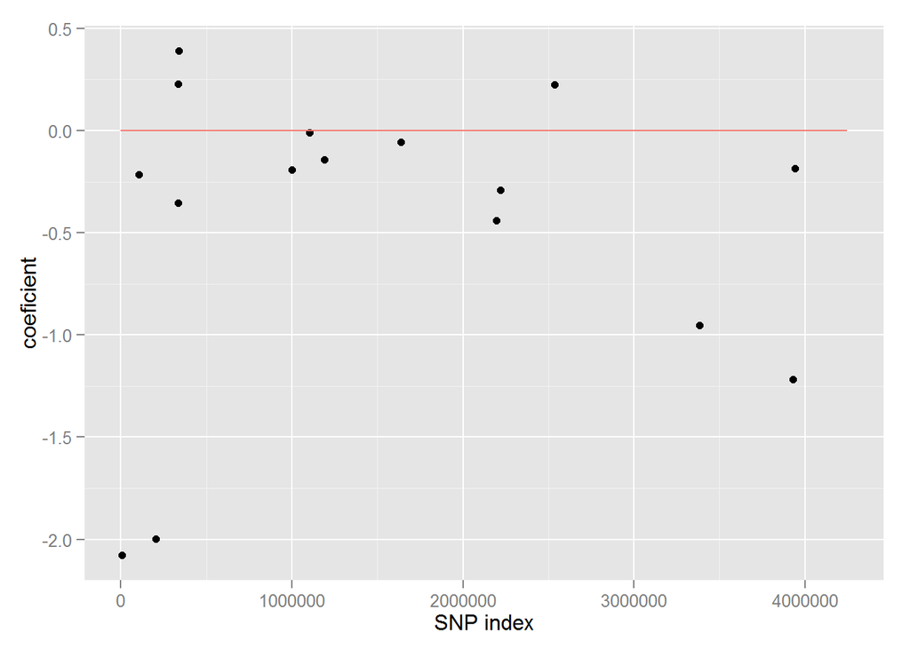

ROC curve for full model

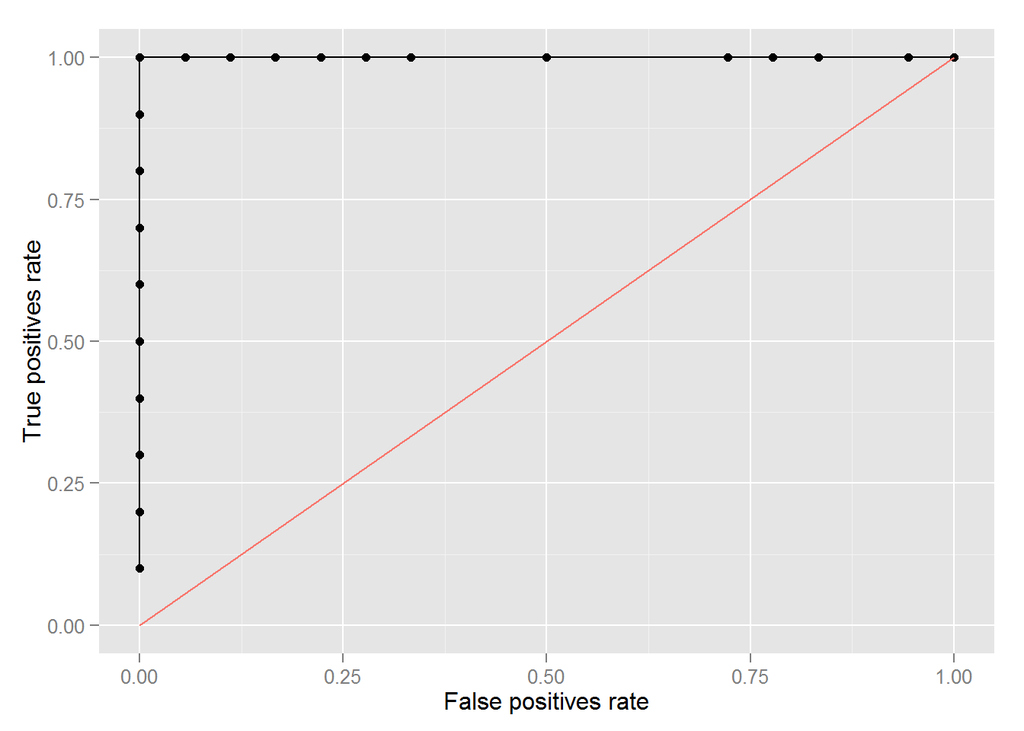

ROC curve for reduced model

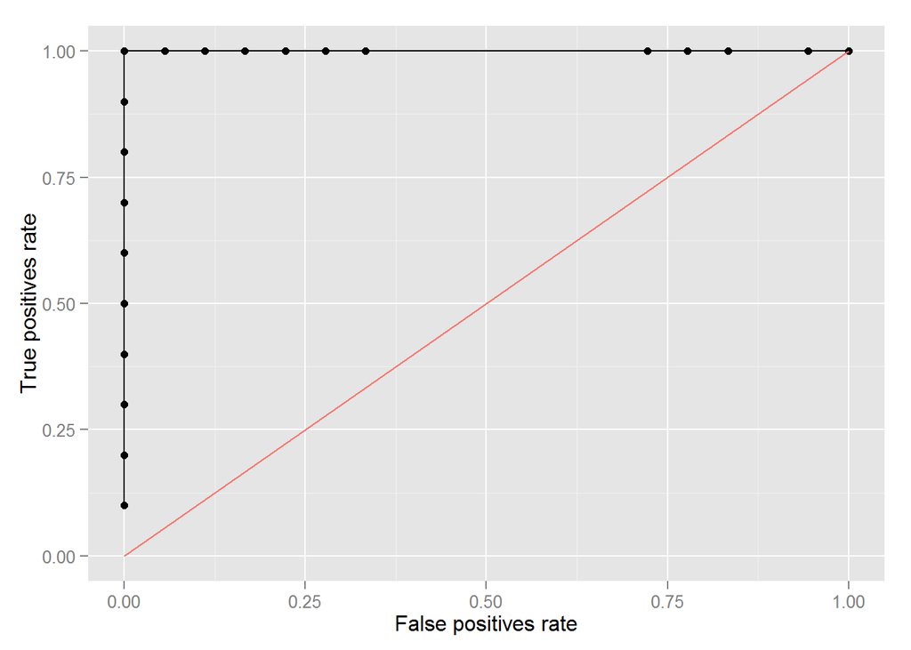